# Analiza transkacji kartami kredytowymi

30/04/2021

# Część pierwsza

## Wstępny przegląd zbioru danych

Należy zacząć od tego, iż analizowany zbiór danych dotyczy transakcji dokonywanych kartami płatniczymi na terenie Europy w sierpniu 2013r. Zawiera 30 kolumn, które możemy traktować jako potencjalne czynniki oraz jedna kolumnę, która dzieli zbiór danych na dwie grupy. Pierwsza z grup dotyczy transakcji, które zostały zweryfikowane jako próba nadużycia, oszustwo. Reszta obserwacji dotyczy transakcji “czystych”.

### Opis zmiennych

#### V1-V28

Zmienne *V1-V28* to szczegółowe informacje dotyczące przeprowadzonych transakcji, ze względów bezpieczenśtwa, dane zostały poddane licznym transformacjom (autor wspomina m.in o PCA). Poniżej przedstawiono wykresy pudełkowe wybranych zmiennych dla obu grup obserwacji (lewa strona odnosi się do transakcji uczciwych, a prawa - oszustw).

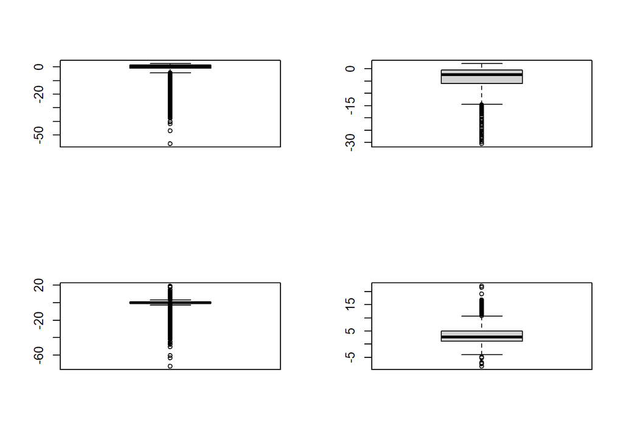

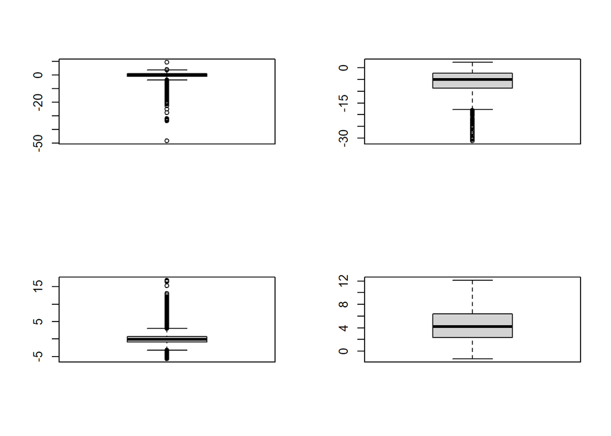

Analizując podzbiór wykresów można jedynie stwierdzić, iż w niektórych przypadkach istnieją zauważalne różnice między grupami. Brakło niestety miejsca na szerszą analizę poszczególnych zmiennych objaśniających, głównie ze względu, iż dane te zostały w pewien sposób zaszyfrowane, a więc trudno byłoby o praktyczne wnioski, jak i również wysnucie pewnych hipotez, na tej podstawie.

#### Amount

Jeśli chodzi o jedyną jawną zmienną pośród analizowanego zbioru predyktorów - zmienna *Amount* jak sama jej nazwa zawiera informację o kwocie, której dotyczyła transakcja. Ze względu na to, iż zmienna *Amount* to jedyny predyktor w modelu, który nie został podany zabiegom transformacyjnym, znacznie odbiega on wartościami od reszty. W takiej sytuacji zdecydowano o jej standaryzacji. Wykresydotyczą wartości zmiennej przed standaryzacją (w celu lepszej wizualizacji).

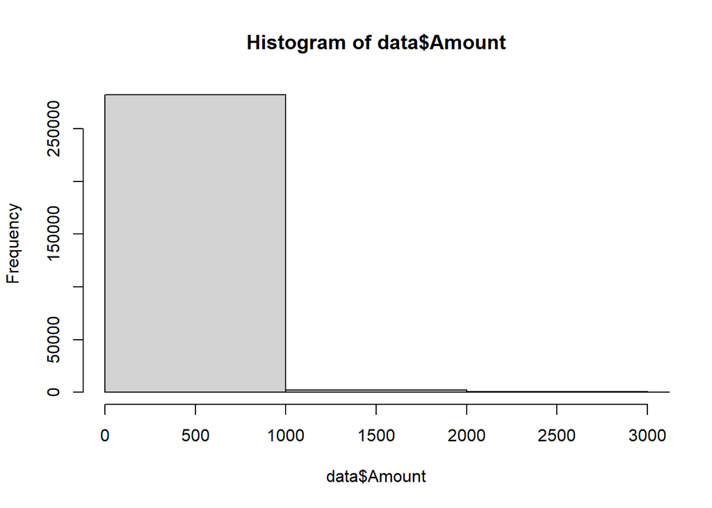

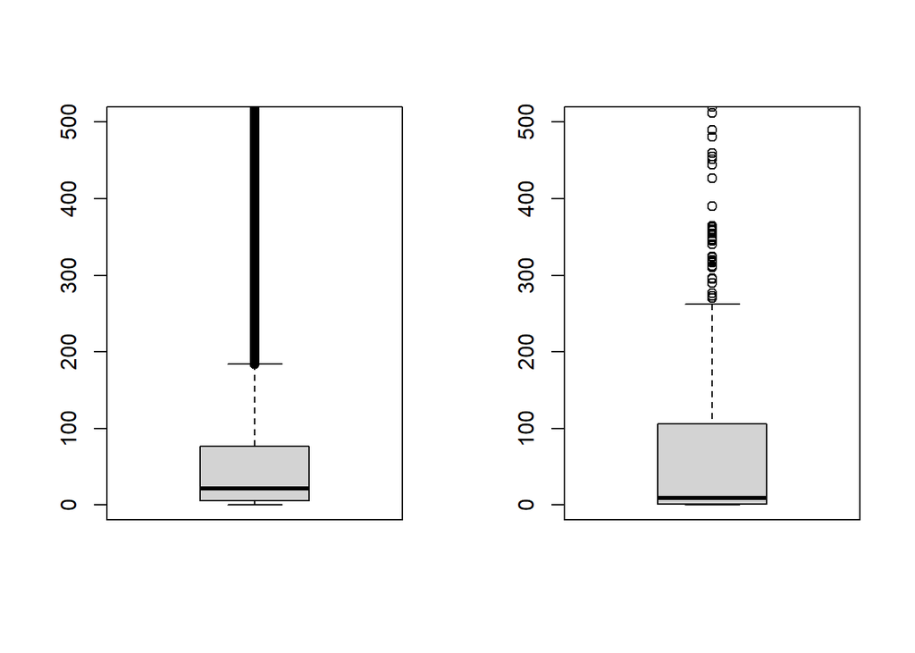

W analizowanym zbiorze zdecydowana większość transakcji opiewa na kwoty o wartości <1000 . Widząc wykres pudełkowy, cięzko wychwywić jakiekolwiek różnice zmiennej *Amount* pomiędzy grupami. Co ciekawe, odwrotnie do intuicji - mediana transakcji jest dużo niższa dla tych o podłożu oszustwa. Z wykresu wynika również, iż sporo transakcji w obu grupach leży poza trzecim kwartylem, co można by uznać problem outlierów. Warto przypomnieć jednak, iż analizowany jest wielowymiarowy zbiór predyktorów, a więc zrealizowane zostanie inne podejście do oberwacji odstających.

### Braki danych

Mierząc się z wybranym zbiorem danych nie natknięto się na brakujące dane - wszystkie obserwacje były kompletne.

### Rozkład zmiennej objaśnianej

Należy w pierwszej kolejności zwrócić uwagę na pewien problem związany z rozkładem obserwacji, jeśli chodzi o zmienną determinującą, czy transakcja jest oflagowana jako oszustwo.

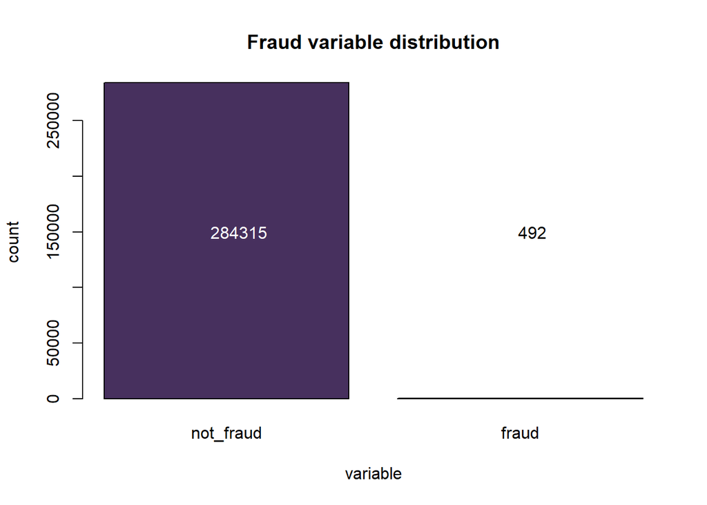

Jak widać na załączonym wykresie, wybrany zbiór danych wykazuje cechy całkowicie niezbilansowanego, jedynie 492 transakcje spośród całego zbioru oznaczone są jako “fraud” (stanowi to około 0.17%). Taki stan rzecz z bardzo dużym prawdopodobieństwem powodował będzie w stworzonych modelach bardzo wysoki odsetek poprawności klasyfikacji, aczkolwiek statystyka ta będzie całkowicie nieprzydatna, gdyż już na tym etapie można domniemywać, iż obserwacje “1” będą klasyfikowane w dużej mierze nieprawidłowo, a wynik zawyżany będzie przez prawidłową klasyfikację transakcji regularnych, których jest zdecydowana większość. Istnieją, co prawda miary statystyczne odporne na taki stan rzeczy (takie jak krzywa ROC), aczkolwiek na tym etapie postanowiono poczynić pewne działania w celu poprawy sytuacji już w początkowej fazie.Zdecydowano się na takie działania ze względu na praktyczne aspekty modeli dotyczących tego typu danych. Otóż charakterystyka analizowanego zbiory danych implikuje szczególne zwrócenie uwagi na oberwacje fałszywie negatywnie (false negatives) zaklasyfikowane. W praktyce dużo większym problemem zdaje się być niewykrycie transakcji o podłożu oszustwa, niż sytuacja odwrotna (co wygenerować może jedynie koszty częstszej manualnej weryfikacji transakcji, czy też zwiększone niezadowolenie ze strony uczciwych klientów, których czas realizacji transakcji z tego względu zapewne się wydłuży). Na potrzeby dalszej części badań postanowiono wyodrębnić ze zbioru danych podpróbę. Zdecydowano więc wykonać tzw. **under-sampling**, który w tym przypadku polegał na wyodrębnieniu wszystkich transakcji typu *fraud* i dolosowanie do nich takiej samej ilości transakcji *non-fraud* spośród reszty zbioru. W tak utworzonym podzbiorze rozkład zmiennej objaśnianej przyjmuje proporcje 50/50.

### Obserwacje odstające

Zadecydowano zbadać jak wygląda rozkład obserwacji pod kątem ewentualnych danych odstających. Wykorzystano do tego miarę, jaką jest odegłość Mahalanobisa.

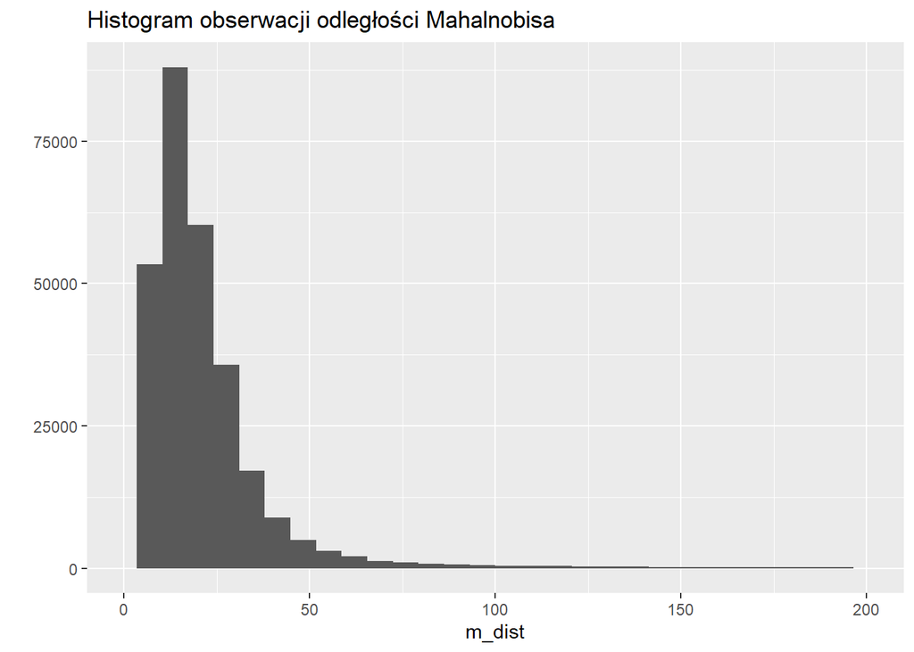

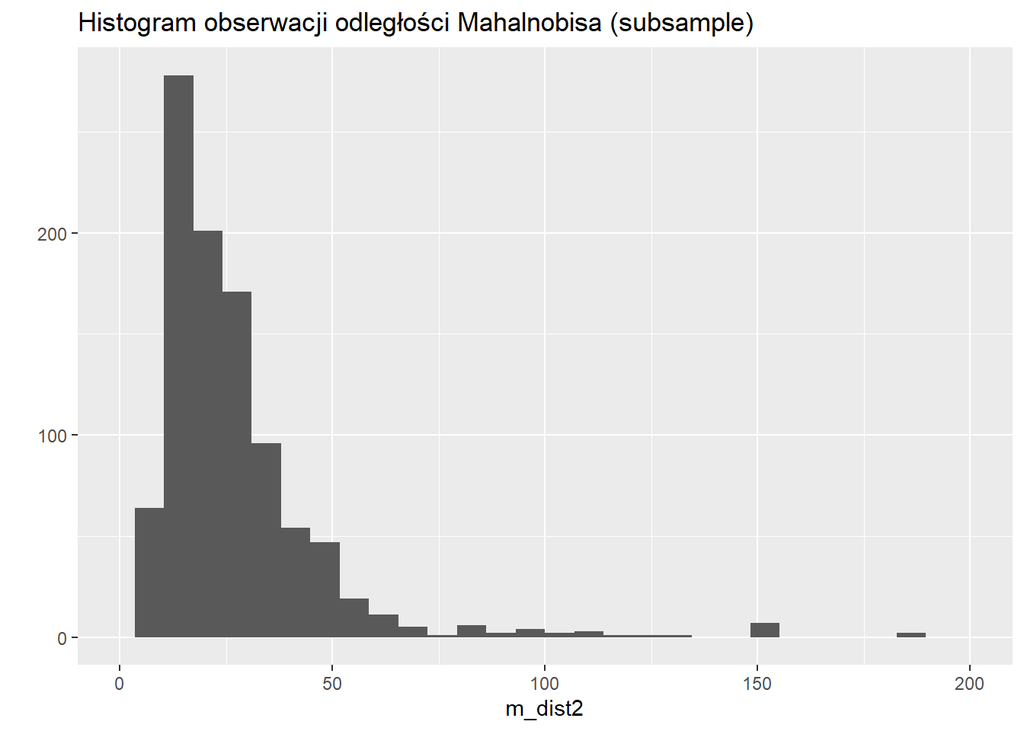

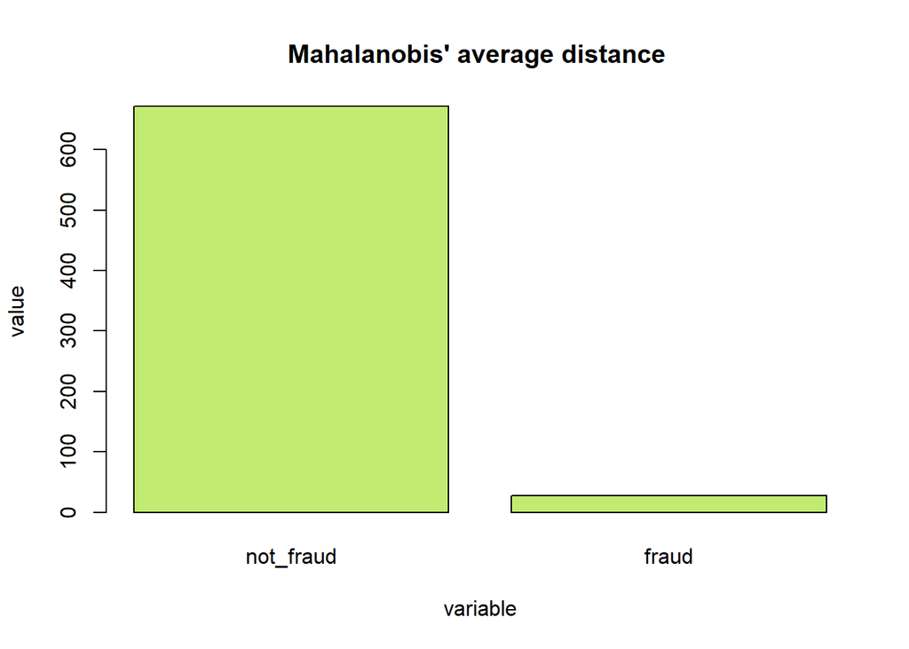

### Podstawowe statystyki

```
##         mean     sd median     min      max  skew kurtosis   se
## V1      0.00   1.96   0.02  -56.41     2.45 -3.28    32.49 0.00
## V2      0.00   1.65   0.07  -72.72    22.06 -4.62    95.77 0.00
## V3      0.00   1.52   0.18  -48.33     9.38 -2.24    26.62 0.00
## V4      0.00   1.42  -0.02   -5.68    16.88  0.68     2.64 0.00
## V5      0.00   1.38  -0.05 -113.74    34.80 -2.43   206.90 0.00
## V6      0.00   1.33  -0.27  -26.16    73.30  1.83    42.64 0.00
## V7      0.00   1.24   0.04  -43.56   120.59  2.55   405.60 0.00
## V8      0.00   1.19   0.02  -73.22    20.01 -8.52   220.58 0.00
## V9      0.00   1.10  -0.05  -13.43    15.59  0.55     3.73 0.00
## V10     0.00   1.09  -0.09  -24.59    23.75  1.19    31.99 0.00
## V11     0.00   1.02  -0.03   -4.80    12.02  0.36     1.63 0.00
## V12     0.00   1.00   0.14  -18.68     7.85 -2.28    20.24 0.00
## V13     0.00   1.00  -0.01   -5.79     7.13  0.07     0.20 0.00
## V14     0.00   0.96   0.05  -19.21    10.53 -2.00    23.88 0.00
## V15     0.00   0.92   0.05   -4.50     8.88 -0.31     0.28 0.00
## V16     0.00   0.88   0.07  -14.13    17.32 -1.10    10.42 0.00
## V17     0.00   0.85  -0.07  -25.16     9.25 -3.84    94.80 0.00
## V18     0.00   0.84   0.00   -9.50     5.04 -0.26     2.58 0.00
## V19     0.00   0.81   0.00   -7.21     5.59  0.11     1.72 0.00
## V20     0.00   0.77  -0.06  -54.50    39.42 -2.04   271.01 0.00
## V21     0.00   0.73  -0.03  -34.83    27.20  3.59   207.28 0.00
## V22     0.00   0.73   0.01  -10.93    10.50 -0.21     2.83 0.00
## V23     0.00   0.62  -0.01  -44.81    22.53 -5.88   440.08 0.00
## V24     0.00   0.61   0.04   -2.84     4.58 -0.55     0.62 0.00
## V25     0.00   0.52   0.02  -10.30     7.52 -0.42     4.29 0.00
## V26     0.00   0.48  -0.05   -2.60     3.52  0.58     0.92 0.00
## V27     0.00   0.40   0.00  -22.57    31.61 -1.17   244.98 0.00
## V28     0.00   0.33   0.01  -15.43    33.85 11.19   933.37 0.00
## Amount 88.35 250.12  22.00    0.00 25691.16 16.98   845.07 0.47
```

Ze względu na fakt, iż badanie przeprowadzane jest dla wartości już zestanadaryzowanych trudno o intepretację większości statystyk przedstawionych przez funkcję **describe**. Jedynie w przypadku predyktora mowiącego o kwocie możliwe jest wyciągniecie kilku istotnych informacji. Średnia kwota transakcji kartą w sierpniu 2013 na terenie Europy wyniosła około 88 jednostek waluty (informacja to nie została określona). Odchylenie standardowe mówi w tym wypadku o przeciętnym odchyle o 250 jednostek od średniej. W badanym zbiorze wystapiły transakcje o kwotach z zakresu 0-25691. Dla tej zmiennej występuje także zjawisko prawostronnej asymetrii, czyli większość obserwacji leży poniżej średniej.

```
##          mean     sd median    min     max  skew kurtosis   se
## V1      -2.41   5.51  -0.81 -30.55    2.33 -2.61     7.49 0.18
## V2       1.78   3.72   0.93 -15.73   22.06  1.70     5.54 0.12
## V3      -3.50   6.23  -1.34 -31.10    3.80 -2.18     4.95 0.20
## V4       2.20   3.25   1.30  -4.00   12.11  0.85     0.13 0.10
## V5      -1.61   4.19  -0.46 -22.11   11.10 -2.28     6.18 0.13
## V6      -0.72   1.73  -0.64  -6.41    6.47  0.43     2.18 0.06
## V7      -2.77   5.86  -0.63 -43.56    6.23 -2.74     9.53 0.19
## V8       0.30   4.86   0.14 -41.04   20.01 -3.68    33.37 0.16
## V9      -1.34   2.28  -0.77 -13.43    4.31 -1.43     3.01 0.07
## V10     -2.80   4.55  -0.84 -24.59    6.19 -1.76     3.38 0.15
## V11      1.89   2.78   1.09  -2.45   12.02  1.04     0.70 0.09
## V12     -3.12   4.59  -0.83 -18.68    2.74 -1.36     1.12 0.15
## V13     -0.08   1.04  -0.04  -3.13    3.12  0.02    -0.22 0.03
## V14     -3.48   4.66  -0.97 -19.21    3.92 -1.01     0.04 0.15
## V15     -0.03   0.97   0.02  -4.50    2.47 -0.51     0.56 0.03
## V16     -2.06   3.48  -0.64 -14.13    3.14 -1.38     1.23 0.11
## V17     -3.33   5.97  -0.50 -25.16    6.74 -1.51     1.60 0.19
## V18     -1.14   2.40  -0.35  -9.50    3.79 -1.39     1.54 0.08
## V19      0.38   1.26   0.25  -3.68    5.23  0.46     0.79 0.04
## V20      0.18   1.07   0.04  -6.98   11.06  2.31    25.95 0.03
## V21      0.35   2.79   0.17 -22.80   27.20  3.90    61.41 0.09
## V22      0.03   1.17   0.03  -8.89    8.36 -1.57    25.01 0.04
## V23     -0.04   1.27  -0.04 -19.25    5.47 -7.58   111.78 0.04
## V24     -0.05   0.56   0.00  -2.03    1.65 -0.55     0.36 0.02
## V25      0.00   0.67   0.05  -4.78    2.21 -0.75     4.59 0.02
## V26      0.02   0.47  -0.03  -1.15    2.75  0.64     1.54 0.02
## V27      0.07   1.02   0.05  -7.26    3.05 -2.63    14.50 0.03
## V28      0.05   0.49   0.04  -3.01    5.68  1.72    27.05 0.02
## Amount 109.88 255.33  18.14   0.00 3360.00  5.31    41.77 8.14
```

### Korelacja

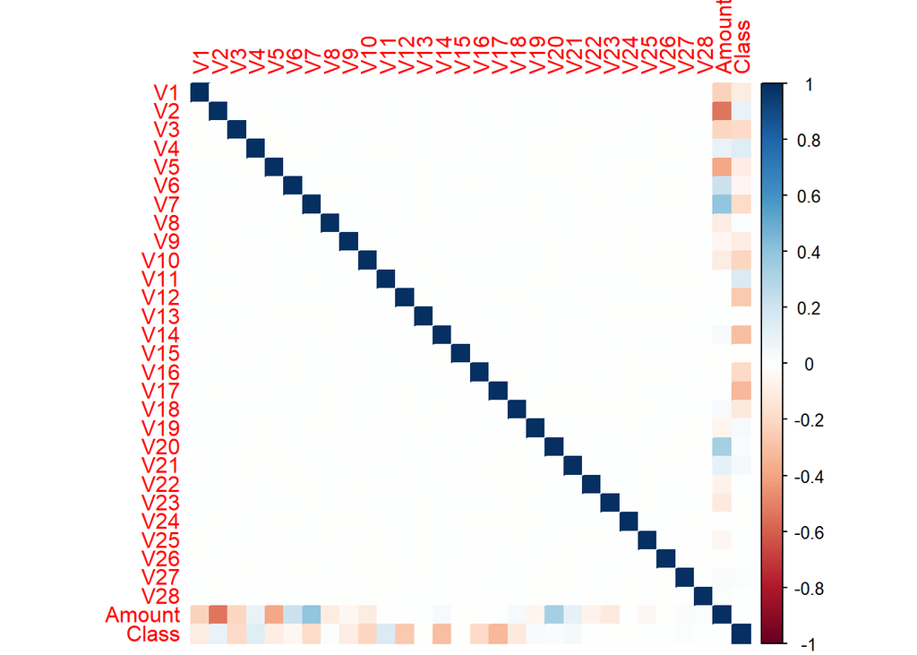

Analizując macierz korelacji, nie zauważa się żadnych wymagających interwencji sytuacji. Pomiędzy pozostałymi zmiennymi objaśniającymi korelacja występuje w stopniu nieznacznym. Zauważalne jest, iż anonimowe zmienne V1-V28 są w jakimś stopniu powiązane z kwotą transakcji. Jeśli chodzi o wartości statystyki dot. korelacji dla zmiennej objaśnianej - ta część wykresu zalicza się do istotnie ciemniejszych w odniesieniu do pozostałych. Co prawda, nie w każdym przypadku korelacja ze zmienną objaśnianą jest na satysfakcjonującym poziomie (jeśli chodzi o teoretyczne podejście do budowy modelu) lecz ze względu, iż dane nie są dostępne w oryginalnej formie, a jedynie po serii przekształceń (m.in PCA) postanowiono nie usuwać z tego powodu żadnego potencjalnego predyktora.

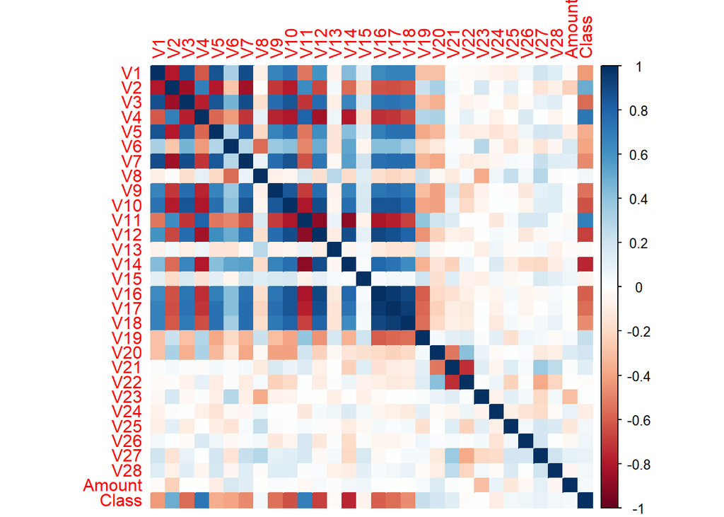

Przeanalizowano również macierz korelacji podpróby, gdzie zmienna odpowiedzialna za podział na klasy jest w równych proporcjach, daje to kompletnie inny obraz sytuacji niż w przypadku analizy całości zbioru. Na potrzeby projektu, pominięto analizę tej macierzy korelacji. Kontynuując badanie nad zbiorem danych w przyszłości można by na tej podstawie przyjrzeć się dokładniej poszególnym zmiennym z grupy V1-V28 i popracować np. nad outlierami w celu poprawy jakości klasyfikacji.

### Zmienność

Zmienność poszczególnych predyktorów używanych do budowy modelu, odwołując się teorii, powinna przekraczać poziom 10%.

```
##            V1            V2            V3            V4            V5
##  1.679004e+15  5.294369e+15 -1.112074e+15  6.706037e+14  1.408848e+15
##            V6            V7            V8            V9           V10
##  8.822768e+14 -2.281674e+15  1.163244e+16 -4.535192e+14  4.891347e+14
##           V11           V12           V13           V14           V15
##  5.981657e+14 -8.038294e+14  1.191505e+15  7.801949e+14  1.889616e+14
##           V16           V17           V18           V19           V20
##  6.111940e+14 -2.248541e+15  8.587290e+14  7.838789e+14  1.203316e+15
##           V21           V22           V23           V24           V25
##  4.356139e+15 -2.146649e+15  2.335764e+15  1.353441e+14  1.020968e+15
##           V26           V27           V28        Amount
##  2.862516e+14 -1.098816e+15 -2.682718e+15  1.297554e+16
```

Jak już było to widoczne powyżej, zbiór charakteryzuje się bardzo wysoka zmiennością poszczególnych zmiennych.

## Tuningowanie hiperparametrów

### Podpróbka

```
## Confusion Matrix and Statistics
##
##           Reference
## Prediction   0   1
##          0 133  11
##          1  24 128
##
##                Accuracy : 0.8818
##                  95% CI : (0.8394, 0.9162)
##     No Information Rate : 0.5304
##     P-Value [Acc > NIR] : < 2e-16
##
##                   Kappa : 0.7639
##
##  Mcnemar's Test P-Value : 0.04252
##
##             Sensitivity : 0.8471
##             Specificity : 0.9209
##          Pos Pred Value : 0.9236
##          Neg Pred Value : 0.8421
##              Prevalence : 0.5304
##          Detection Rate : 0.4493
##    Detection Prevalence : 0.4865
##       Balanced Accuracy : 0.8840
##
##        'Positive' Class : 0
##
```

```
## k-Nearest Neighbors
##
## 688 samples
##  29 predictor
##   2 classes: '0', '1'
##
## No pre-processing
## Resampling: Cross-Validated (5 fold)
## Summary of sample sizes: 551, 551, 550, 550, 550
## Resampling results across tuning parameters:
##
##   k  Accuracy   Kappa
##   5  0.8837406  0.7678771
##   7  0.8706866  0.7417155
##   9  0.8721358  0.7445590
##
## Accuracy was used to select the optimal model using the largest value.
## The final value used for the model was k = 5.
```

```
## k-Nearest Neighbors
##
## 688 samples
##  29 predictor
##   2 classes: '0', '1'
##
## No pre-processing
## Resampling: Cross-Validated (5 fold, repeated 3 times)
## Summary of sample sizes: 550, 551, 551, 550, 550, 550, ...
## Resampling results across tuning parameters:
##
##   k  Accuracy   Kappa
##   5  0.8963398  0.7929492
##   7  0.8866356  0.7735868
##   9  0.8808385  0.7619192
##
## Accuracy was used to select the optimal model using the largest value.
## The final value used for the model was k = 5.
```

### Cały zbiór

```
## Confusion Matrix and Statistics
##
##           Reference
## Prediction      0      1
##          0 274215    192
##          1    119    281
##
##                Accuracy : 0.9989
##                  95% CI : (0.9987, 0.999)
##     No Information Rate : 0.9983
##     P-Value [Acc > NIR] : 1.179e-15
##
##                   Kappa : 0.6432
##
##  Mcnemar's Test P-Value : 4.451e-05
##
##             Sensitivity : 0.9996
##             Specificity : 0.5941
##          Pos Pred Value : 0.9993
##          Neg Pred Value : 0.7025
##              Prevalence : 0.9983
##          Detection Rate : 0.9978
##    Detection Prevalence : 0.9985
##       Balanced Accuracy : 0.7968
##
##        'Positive' Class : 0
##
```

```
## k-Nearest Neighbors
##
## 10000 samples
##    29 predictor
##     2 classes: '0', '1'
##
## No pre-processing
## Resampling: Cross-Validated (5 fold)
## Summary of sample sizes: 8000, 8000, 8000, 7999, 8001
## Resampling results across tuning parameters:
##
##   k  Accuracy   Kappa
##   5  0.9983002  0.3537275
##   7  0.9983002  0.4070084
##   9  0.9981002  0.3326398
##
## Accuracy was used to select the optimal model using the largest value.
## The final value used for the model was k = 7.
```

```
## k-Nearest Neighbors
##
## 10000 samples
##    29 predictor
##     2 classes: '0', '1'
##
## No pre-processing
## Resampling: Cross-Validated (5 fold, repeated 3 times)
## Summary of sample sizes: 8000, 8001, 7999, 8000, 8000, 8000, ...
## Resampling results across tuning parameters:
##
##   k  Accuracy   Kappa
##   5  0.9986334  0.5308835
##   7  0.9985000  0.4519196
##   9  0.9982000  0.3999602
##
## Accuracy was used to select the optimal model using the largest value.
## The final value used for the model was k = 5.
```

# Część druga

W kolejnej części pracy postanowiono zbadać jakie wyniki można otrzymać podchodząc do budowy modelu stosując następujące metody:

- metoda k najbliższych sąsiadów,
- LDA ,
- QDA ,
- regresja logistyczna.

## Metoda k-najbliższych sąsiadów (KNN)

Zaczęto z naturalnych powodów od wspomnianej już wcześniej metody k-najbliższych sąsiadów.

Jeśli chodzi o krótki teoretyczny wstęp do tej techniki, jest to jeden z algorytmów regresji nieparametrycznej. Może być używany zarówno do klasyfikacyjnych celów, jak i prognozowania. Algorytm w dużej mierze polega na porównywaniu wartości zmiennych objaśniających dla pojedynczej obserwacji z wartościami tych zmiennych dla pozostałych obserwacji w zbiorze uczącym. Duże znaczenie w algorytmie ma wartość parametru, który przyjmuje - mowa o parametrze k. Ustalany jest on z góry, a jedną z technik jego wyboru może być np. tuningowanie hiperparametryczne (co zastosowano powyżej).

Do budowy modelu użyto wybranego powyżej parametru k = 5.

```
##           Prediction
## Real value   0   1
##          0 139  18
##          1  15 124
```

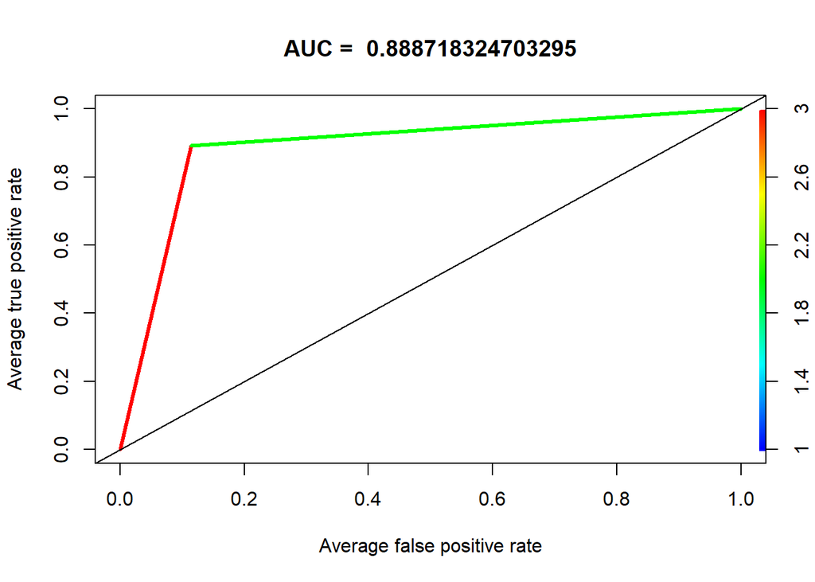

## Metoda LDA

Analiza dyskryminacyjna w statystyce określana jest jako metoda realizująca dwa podstawowe zadania: badanie różnic pomiędzy obserwacjami należącymi do poszczególnych grup (dwóch lub więcej), jak i również konstruowanie możliwie najlepszej reguły przydziału obserwacji o nieznanej klasie, do już istniejącej (Koronacki i Ćwik, 2005). Problematykę tą zainicjował znany matematyk - Ronald Fischer, autor również innej, powszechnie stosowanej analizy statystycznej, dotyczącej wariancji. W stworzonym przez Fischera algorytmie liniowej analizy dyskryminacyjnej (LDA) koncepcja oparta jest na utworzeniu reguły dyskryminacyjnej na podstawie próby uczącej, przy wykorzystaniu funkcji liniowej. Reguła ta ma za zadanie przyporządkować nowe obserwacje do jednej z grup (z góry określonych). Warto zaznaczyć, iż w podejściu Fischera dopuszcza się podział obserwacji na jedynie dwie grupy.

Główne założenia omawianej metody są następujące: o wielowymiarowy rozkład normalnych danych, o równość kowariancji w grupach, o brak zjawiska współliniowości wśród zmiennych objaśniających, o odpowiednia ilość obserwacji (większa od ilości zmiennych o co najmniej dwa), o liczność każdej z grup na poziomie dwa lub więcej, o obserwacje należące do grup wzajemnie się wykluczających. Odnosząc się do dwóch początkowych punktów - automatycznie uniemożliwiają one stosowanie w modelach zmiennych objaśniających o charakterze jakościowym, aczkolwiek badacze podkreślają (Koronacki i Ćwik, 2005), iż *analiza dyskryminacyjna potrafi dawać sensowne rezultaty w poszczególnych przypadkach także dla danych niespełniających tych założeń*.

Odnosząc się do wymienionych założeń - większość z nich z góry jest spełniona, jeśli chodzi o wielowymiarowy rozkład normalny, która bywa największą przeszkodzą w stosowaniu omawianej metody - biorąc pod uwagę specyfikę analizowanego zbioru danych, cel budowy modelu (detekcja transakcji o podłożu oszustwa, która stanowi nieznaczną część zbioru danych), jak i również doświadczenie poprzednich badaczy postanowiono użyć tej metody z pominięciem rozważań nt. rozkładu wielowymiarowego.

```
##           Prediction
## Real value   0   1
##          0 150   7
##          1  20 119
```

```
## [1] 0.9087838
```

```
## Area under the curve: 0.9501
```

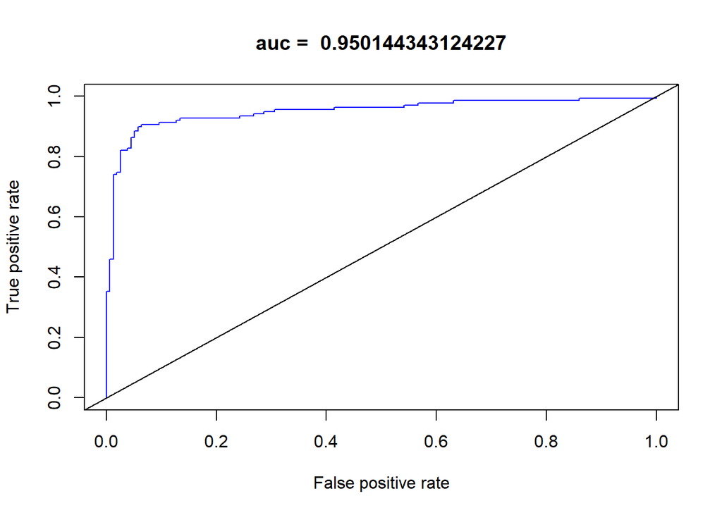

## Metoda QDA

Metoda QDA to modyfikacja LDA, którą wyczerpująco opisano powyżej. Podstawowa różnica, w skrócie polega na tym, iż nie jest wymagana stała wariancja w grupach, qda używa natomiast dla każdej podpopulacji osobnej wartości. Inną ważną, z perpektywy praktycznej różnicą, która jest fakt, iż QDA (Quadratic Discriminant Analysis) dopasowuje kwadratową funkcję dyskryminacyjną, co w zestawieniu do zwykłej prostej (LDA) może lepiej izolować obserwacje w grupach.

```
##           Prediction
## Real value   0   1
##          0 143  14
##          1  11 128
```

```
## [1] 0.9155405
```

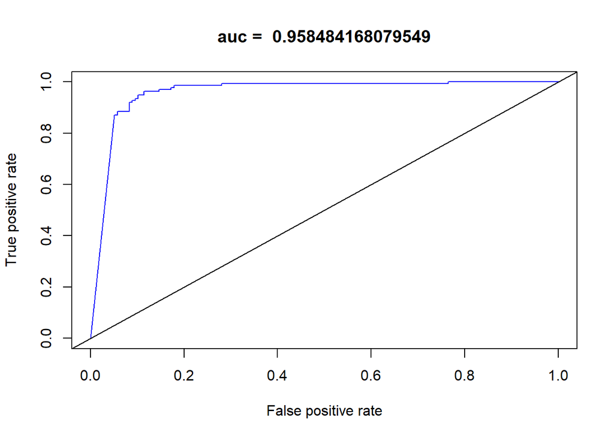

## Regresja logistyczna

Model regresji logistycznej to jeden z najczęściej używanych algorytmów w kategoriiproblemów klasyfikacyjnych. W podstawowej wersji, stosowany jest, gdy zmienna objaśniana reprezentowana jest przez dokładnie dwie wartości. Dodatkowym faktem,różnicującym ten rodzaj regresji od jej liniowej odmiany, jest możliwość otrzymaniana podstawie zestawu predyktorów, prawdopodobieństwa (p) pewnego zdarzenia,zamiast przewidywania konkretnej wartości. W kategoriach oceny jakości dopasowania modeli logitowych, stosowane są miary bazujące na odchyleniu modelu (ang. model deviance). Jedną z nich jest kryterium Akaike, które przyjmuje tym mniejszą wartość, im lepsze dopasowanie. Kryterium AIC określa jako:

$AIC = devω + 2 (p + 1)$,

gdzie devω to dewiancja badanego modelu, a p + 1 to liczba parametrów modelu. Obciążenie o podwojoną liczbę parametrów jest stosowane ze względu na oczywisty wpływ zmniejszania się odchylenie, w przypadku dodawania nowych zmiennych do modelu.

Dzięki liniowej zależności logarytmu szans od zmiennych , interpretacja współczynników przy nich stojących sprowadza się do mówienia o wpływie zmiany o jednostkę czynnika, wyrażonego przez $x_i$ na zmianę wartości logarytmu. Jeśli chodzi o rozpatrywanie terminu ilorazu szans, wyrażenia $𝑒^{𝛽_i}$ zwiększają prawdopodobieństwo wystąpienia rozpatrywanego zjawiska, w momencie, gdy osiągają wartości większe niż 1, zachowują neutralny wpływ przy poziomie równym liczbie jeden, a w pozostałych przypadkach mówi się o ograniczającym wpływie na badane zjawisko. O wpływie jednostkowej zmiany wartości zmiennej wspomina (Hosmer i Lemeshow, 2000).

Wspomnianego już kryterium AIC użyto do metody krokowej wstecz w celu wyboru optymalnego podzbioru zmiennych objaśniających. Wynikiem działania tej metody odrzucono jedynie zmienną *V5*.

```
##
## Call:
## glm(formula = Class ~ V1 + V2 + V3 + V4 + V6 + V7 + V8 + V9 +
##     V10 + V11 + V12 + V13 + V14 + V15 + V16 + V17 + V18 + V19 +
##     V20 + V21 + V22 + V23 + V24 + V25 + V26 + V27 + V28 + Amount,
##     family = "binomial", data = train)
##
## Deviance Residuals:
##     Min       1Q   Median       3Q      Max
## -1.7713  -0.1518   0.0000   0.0000   3.5069
##
## Coefficients:
##              Estimate Std. Error z value Pr(>|z|)
## (Intercept)  -420.098    151.834  -2.767  0.00566 **
## V1             77.083     28.304   2.723  0.00646 **
## V2            636.902    231.426   2.752  0.00592 **
## V3           -273.032     99.125  -2.754  0.00588 **
## V4            216.268     78.395   2.759  0.00580 **
## V6           -290.979    105.706  -2.753  0.00591 **
## V7          -1016.683    369.634  -2.751  0.00595 **
## V8            175.554     63.636   2.759  0.00580 **
## V9           -317.955    115.683  -2.749  0.00599 **
## V10          -732.379    266.149  -2.752  0.00593 **
## V11           614.558    223.439   2.750  0.00595 **
## V12         -1103.985    401.318  -2.751  0.00594 **
## V13           -27.057      9.760  -2.772  0.00557 **
## V14         -1202.151    436.794  -2.752  0.00592 **
## V15           -42.248     15.260  -2.768  0.00563 **
## V16         -1061.192    385.804  -2.751  0.00595 **
## V17         -1865.115    678.286  -2.750  0.00596 **
## V18          -711.812    258.960  -2.749  0.00598 **
## V19           292.024    106.263   2.748  0.00599 **
## V20          -182.817     66.303  -2.757  0.00583 **
## V21            53.880     19.751   2.728  0.00637 **
## V22           124.758     45.190   2.761  0.00577 **
## V23           374.566    135.868   2.757  0.00584 **
## V24           -35.801     13.222  -2.708  0.00678 **
## V25           173.048     62.892   2.752  0.00593 **
## V26            42.735     15.778   2.708  0.00676 **
## V27           142.775     52.273   2.731  0.00631 **
## V28           456.474    167.009   2.733  0.00627 **
## Amount          4.328      1.573   2.752  0.00593 **
## ---
## Signif. codes:  0 '***' 0.001 '**' 0.01 '*' 0.05 '.' 0.1 ' ' 1
##
## (Dispersion parameter for binomial family taken to be 1)
##
##     Null deviance: 953.30  on 687  degrees of freedom
## Residual deviance: 137.83  on 659  degrees of freedom
## AIC: 195.83
##
## Number of Fisher Scoring iterations: 24
```

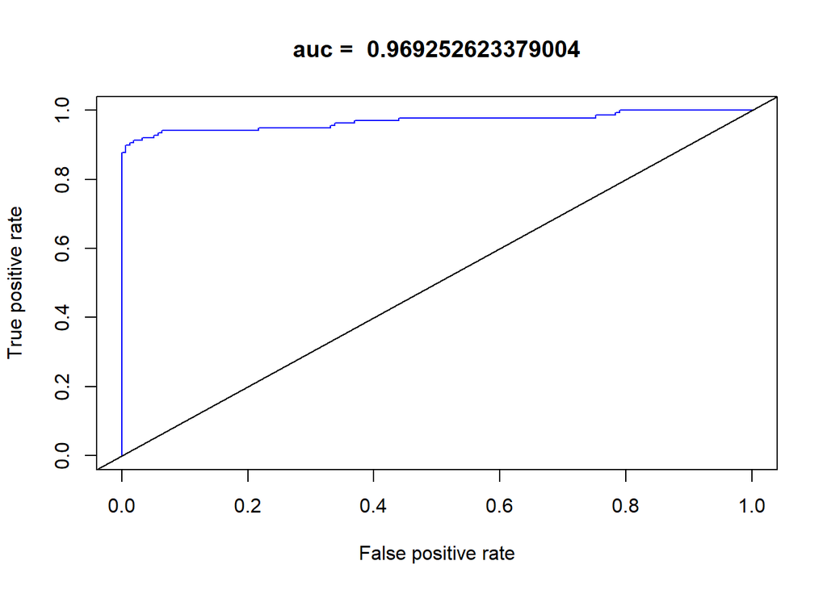

## Porównanie

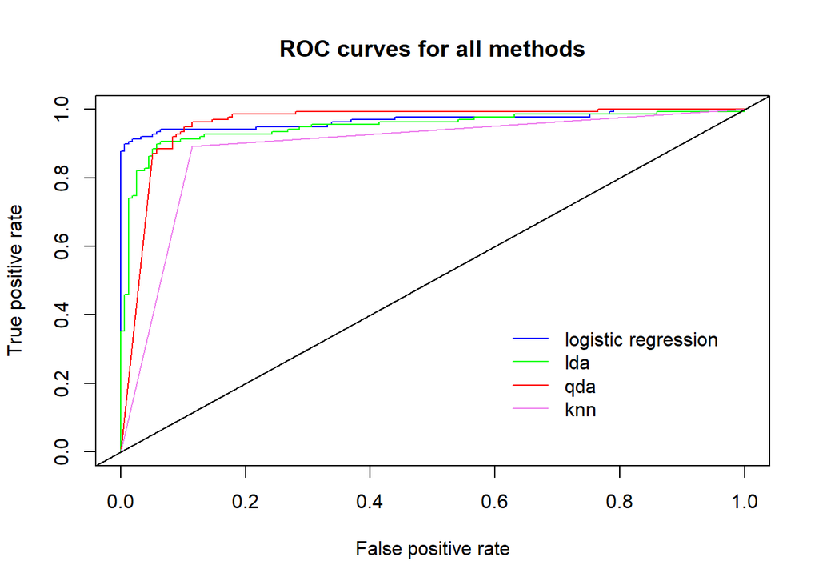

Jak widać, pracując na zbalansowanej podpróbce uzyskano bardzo przyzwoite rezultaty dla każdej z metod(do oceny modeli zadecydowano wybrać wartość statystyki AUC). Najlepszą wartość udało się uzyskać dla modelu otrzymanego metodą regresji logistycznej, a najsłabiej spośród użytych metod wypadł model otrzymany przy użyciu KNN. Jeśli chodzi o metody LDA oraz QDA, które są bardzo powiązane - zastosowanie obu z nich ich pozwoliło uzyskać bardzo dobre, niezwykle zbliżone rezultaty. Należy tutaj zwrócić uwagę, iż użycie paraboli (QDA) pozwoliło uzyskać funkcję, która posiada minimalnie lepsze własności dyskryminacyjne. Postanowiono przytoczyć ponownie parametry finalnego modelu w celu ich interpretacji.

```
##
## Call:
## glm(formula = Class ~ V1 + V2 + V3 + V4 + V6 + V7 + V8 + V9 +
##     V10 + V11 + V12 + V13 + V14 + V15 + V16 + V17 + V18 + V19 +
##     V20 + V21 + V22 + V23 + V24 + V25 + V26 + V27 + V28 + Amount,
##     family = "binomial", data = train)
##
## Deviance Residuals:
##     Min       1Q   Median       3Q      Max
## -1.7713  -0.1518   0.0000   0.0000   3.5069
##
## Coefficients:
##              Estimate Std. Error z value Pr(>|z|)
## (Intercept)  -420.098    151.834  -2.767  0.00566 **
## V1             77.083     28.304   2.723  0.00646 **
## V2            636.902    231.426   2.752  0.00592 **
## V3           -273.032     99.125  -2.754  0.00588 **
## V4            216.268     78.395   2.759  0.00580 **
## V6           -290.979    105.706  -2.753  0.00591 **
## V7          -1016.683    369.634  -2.751  0.00595 **
## V8            175.554     63.636   2.759  0.00580 **
## V9           -317.955    115.683  -2.749  0.00599 **
## V10          -732.379    266.149  -2.752  0.00593 **
## V11           614.558    223.439   2.750  0.00595 **
## V12         -1103.985    401.318  -2.751  0.00594 **
## V13           -27.057      9.760  -2.772  0.00557 **
## V14         -1202.151    436.794  -2.752  0.00592 **
## V15           -42.248     15.260  -2.768  0.00563 **
## V16         -1061.192    385.804  -2.751  0.00595 **
## V17         -1865.115    678.286  -2.750  0.00596 **
## V18          -711.812    258.960  -2.749  0.00598 **
## V19           292.024    106.263   2.748  0.00599 **
## V20          -182.817     66.303  -2.757  0.00583 **
## V21            53.880     19.751   2.728  0.00637 **
## V22           124.758     45.190   2.761  0.00577 **
## V23           374.566    135.868   2.757  0.00584 **
## V24           -35.801     13.222  -2.708  0.00678 **
## V25           173.048     62.892   2.752  0.00593 **
## V26            42.735     15.778   2.708  0.00676 **
## V27           142.775     52.273   2.731  0.00631 **
## V28           456.474    167.009   2.733  0.00627 **
## Amount          4.328      1.573   2.752  0.00593 **
## ---
## Signif. codes:  0 '***' 0.001 '**' 0.01 '*' 0.05 '.' 0.1 ' ' 1
##
## (Dispersion parameter for binomial family taken to be 1)
##
##     Null deviance: 953.30  on 687  degrees of freedom
## Residual deviance: 137.83  on 659  degrees of freedom
## AIC: 195.83
##
## Number of Fisher Scoring iterations: 24
```

```
##           Prediction
## Real value   0   1
##          0 154   3
##          1  12 127
```

Warto zwrócić uwagę, iż zastosowanie metody krokowej wstecz pozwoliło uzyskać całkowicie istotny podzbiór zmiennych objaśniających (kosztem niewielkiej redukcji ilości zmiennych). W kontekście interpretacji przeliczone eksponenty uzyskanych parametrów z modelu.

```r
exp(logit$coefficients) > 1
```

```
## (Intercept)          V1          V2          V3          V4          V6
##       FALSE        TRUE        TRUE       FALSE        TRUE       FALSE
##          V7          V8          V9         V10         V11         V12
##       FALSE        TRUE       FALSE       FALSE        TRUE       FALSE
##         V13         V14         V15         V16         V17         V18
##       FALSE       FALSE       FALSE       FALSE       FALSE       FALSE
##         V19         V20         V21         V22         V23         V24
##        TRUE       FALSE        TRUE        TRUE        TRUE       FALSE
##         V25         V26         V27         V28      Amount
##        TRUE        TRUE        TRUE        TRUE        TRUE
```

```r
sum(exp(logit$coefficients) > 1)
```

```
## [1] 14
```

Jak już wspomniano w części teoretycznej możemy łatwo ocenić wzrost wartości, których parametrów powodował zwiększenie szansy na klasyfikację do grupy “fraud”. Z analizy wynika, iż miało to miejsce w 14 przypadkach, czyli około połowie rozpatrywanych zmiennych. Ze względu na dyskrecję zmiennych V1-V28, można jedynie powiedzieć, iż w przypadku modelu utworzonego przy pomocy regresji logistycznej, rosnące kwoty transakcji powodują wzrost prawdopodobieństwa zaklasyfikowania do nadużyć.

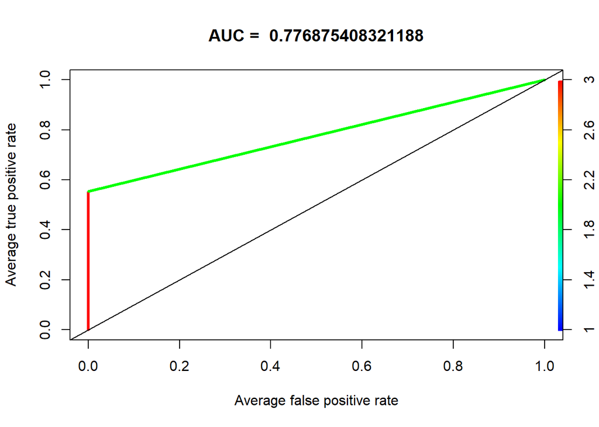

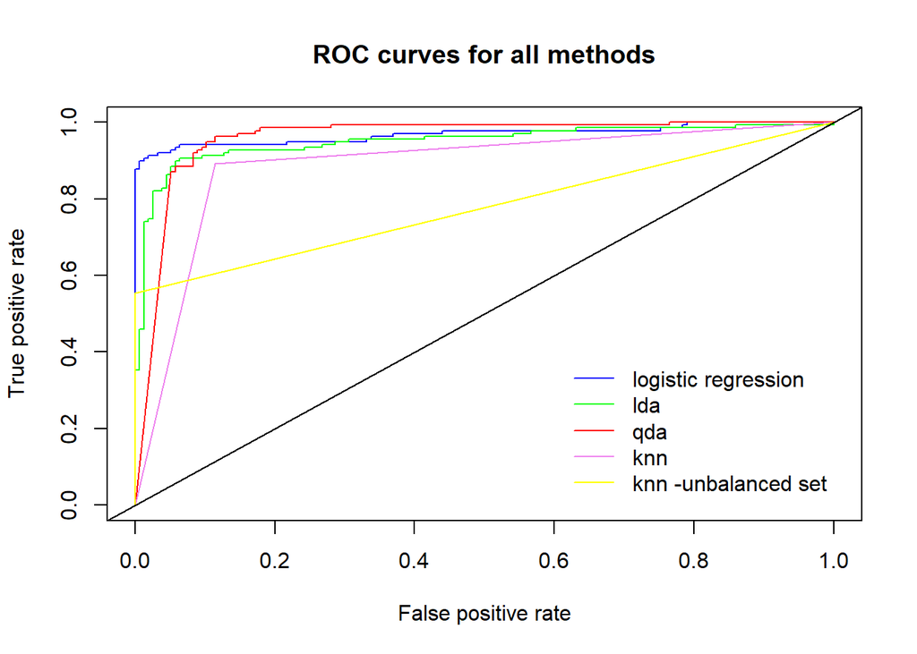

Kolejne etapy badania przeprowadzane zostały dla podzbioru obserwacji otrzymanego w wyniku undersamplingu, na sam koniec zestawiono otrzymane wyniki z rezultatami metody KNN użytej dla próbki reprezentującej całą populację. Próbkę reprezentującą cały zbiór danych poddano działaniu jedynie metody KNN ze względów na ograniczenia techiczne, czasowe. Warto dodać, iż w celu dokładniejszego porównania należałoby przeprowadzić pełną analizę dla zbioru niezbalansowanego (tj. użyć np. tuningowania hiperparametrycznego, użyć przynajmniej kilku różnych metod). Działania te mogłoby być punktem zaczepienia do kontynuoowania badań… Przechodząc jednak do istoty sprawy, tak jak podejrzewano budowanie modeli na zbiorze wysoce niezbalansowanym nie dość, iż daje znacznie gorsze rezultaty jeśli chodzi o wartości AUC, przebieg krzyewj ROC, to w dodatku prowadzi do budowy modeli z nadmiarem obserwacji false negative.

## Bibligrafia

- dane: https://www.kaggle.com/mlg-ulb/creditcardfraud
- Koronacki, J., Ćwik, J. (2005). Statystyczne systemy uczące się, Exit, Warszawa
- Hosmer, D. W., Lemeshow, S. (2000). Applied logistic regression, wyd. 2, Wiley & Sons, Nowy Jork